# BUGS tutorial (by example) part II

João Neto

October 2014

Let’s repeat the essential code here:

```r
library(BRugs)
```

```r
run.model <- function(model, samples, data=list(), chainLength=10000, burnin=0.10,
                      init.func, n.chains=1, thin=1) {

  writeLines(model, con="model.txt")  # Write the modelString to a file
  modelCheck( "model.txt" )           # Send the model to BUGS, which checks the model syntax
  if (length(data)>0)                 # If there's any data available...
    modelData(bugsData(data))         # ... BRugs puts it into a file and ships it to BUGS
  modelCompile(n.chains)              # BRugs command tells BUGS to compile the model

  if (missing(init.func)) {
    modelGenInits()                   # BRugs command tells BUGS to randomly initialize a chain
  } else {
    for (chain in 1:n.chains) {       # otherwise use user's init data
      modelInits(bugsInits(init.func))
    }
  }

  modelUpdate(chainLength*burnin)     # Burn-in period to be discarded
  samplesSet(samples)                 # BRugs tells BUGS to keep a record of the sampled values
  samplesSetThin(thin)                # Set thinning
  modelUpdate(chainLength)            # BRugs command tells BUGS to randomly initialize a chain
}
```

For ploting with error bars:

```r
plot.errors <- function(x, y, e) {
  plot(x, y, pch=19,ylim=c(min(y)*0.75,max(y)*1.2))
  segments(x, y-e,x, y+e)
  width.bar <- mean(e)/10
  segments(x-width.bar,y-e,x+width.bar,y-e)
  segments(x-width.bar,y+e,x+width.bar,y+e)
}
```

## Bayesian Linear Regression

Given a data set $D = (x_1,y_1), \ldots, (x_N,y_N)$ where $x \in \mathbb{R}^d, y \in \mathbb{R}$, a Bayesian Linear Regression models the problem in the following way:

Prior:
$$w \sim \mathcal{N}(0, \sigma_w^2 I_d)$$

$w$ is vector $(w_1, \ldots, w_d)^T$, so the previous distribution is a multivariate Gaussian; and $I_d$ is the $d\times d$ identity matrix.

Likelihood:
$$Y_i \sim \mathcal{N}(w^T x_i, \sigma^2)$$

We assume that $Y_i \perp Y_j | w, i \neq j$

For now we’ll use the precision instead of the variance, $a = 1/\sigma^2$, and $b = 1/\sigma_w^2$. We’ll also assume that $a,b$ are known.

The prior can be stated as
$$p(w) \propto \exp \Big\{ -\frac{b}{2} w^t w \Big\}$$

And the likelihood
$$p(D|w) \propto \exp \Big\{ -\frac{a}{2} (y-Aw)^T (y-Aw) \Big\}$$

where $y = (y_1,\ldots,y_N)^T$ and $A$ is a $n\times d$ matrix where the i-th row is $x_i^T$.

The the posterior is
$$p(w|D) \propto p(D|w) p(w)$$

After many [calculations](https://www.youtube.com/watch?v=nrd4AnDLR3U&list=PLD0F06AA0D2E8FFBA&index=61) we discover that

$$p(w|D) \sim \mathcal{N}(w | \mu, \Lambda^{-1})$$

where ($\Lambda$ is the precision matrix)

$$\Lambda = a A^T A + b I_d$$
$$\mu = a \Lambda^{-1} A^T y$$

Notice that $\mu$ is equal to the $w_{MAP}$ of the regular linear regression, this is because for the Gaussian, the mean is equal to the mode.

Also, we can make some algebra over $\mu$ and get the following equality ($\Lambda = aA^TA+bI_d$):

$$\mu = (A^T A + \frac{b}{a} I_d)^{-1} A^T y$$

and compare with $w_{MLE}$:

$$w_{MLE} = (A^T A)^{-1} A^T y$$

The extra expression in $\mu$ corresponds to the prior. This is similar to the expression for the Ridge regression, for the special case when $\lambda = \frac{b}{a}$. Ridge regression is more general because the technique can choose improper priors (in the Bayesian perspective).

For the predictive posterior distribution:

$$p(y|x,D) = \int p(y|x,D,w) p(w|x,D) dw = \int p(y|x,w) p(w|D) dw$$

it is possible to calculate that

$$y|x,D \sim \mathcal{N}(\mu^Tx, \frac{1}{a} + x^T \Lambda^{-1}x)$$

## Using BUGS

```r
modelString = "
  model {
      for (i in 1:5) {
        y[i] ~ dnorm(mu[i], tau)
        mu[i] <- beta0 + beta1 * (x[i] - mean(x[]))
      }

      # Jeffreys priors
      beta0 ~ dflat()
      beta1 ~ dflat()
      tau   <- 1/sigma2
      log(sigma2) <- 2*log.sigma
      log.sigma ~ dflat()
  }
"

# data
x <- c(  8,  15,  22,  29,  36)  # day of measure
y <- c(177, 236, 285, 350, 376)  # weight in grams

data.list = list(
    x = x,
    y = y
)

# initializations
n.chains <- 1
log.sigmas <- c(0)
betas0 <- c(0)
betas1 <- c(0)

genInitFactory <- function()  {
  i <- 0
  function() {
    i <<- i + 1
    list(
      log.sigma = log.sigmas[i],
      beta0 = betas0[i],
      beta1 = betas1[i]
    )
  }
}

run.model(modelString, samples=c("beta0", "beta1", "sigma2"), data=data.list, chainLength=15000,
          init.func=genInitFactory(), n.chains=n.chains)
```

```
## model is syntactically correct
```

```
## data loaded
```

```
## model compiled
```

```
## Initializing chain 1:
```

```
## model is initialized
```

```
## 1500 updates took 0 s
```

```
## monitor set for variable 'beta0'
```

```
## monitor set for variable 'beta1'
```

```
## monitor set for variable 'sigma2'
```

```
## 15000 updates took 0 s
```

```r
samplesStats(c("beta0", "beta1", "sigma2"))
```

```
##           mean        sd  MC_error val2.5pc  median val97.5pc start sample
## beta0  284.900    8.2160  0.056790  270.100 284.900   300.300  1501  15000
## beta1    7.311    0.8012  0.006087    5.845   7.308     8.783  1501  15000
## sigma2 326.100 1015.0000 37.170000   37.950 144.300  1570.000  1501  15000
```

```r
# Extract chain values:
beta0  <- samplesSample( "beta0" )
beta1  <- samplesSample( "beta1" )
sigma2 <- samplesSample( "sigma2" )

# Posterior prediction [from Kruschke - Doing Bayesian Data Analysis (2010)]
# Specify x values for which predicted y's are needed:
xPostPred <- seq( min(x)-5 , max(x)+5 , length=100 ) # just make a bunch of them
# Define matrix for recording posterior predicted y values at each x value.
# One row per x value, with each row holding random predicted y values.
postSampSize <- length(beta0)
yPostPred <- matrix( 0 , nrow=length(xPostPred) , ncol=postSampSize )
# Define matrix for recording HDI limits of posterior predicted y values:
yHDIlim <- matrix( 0 , nrow=length(xPostPred) , ncol=2 )
# Generate posterior predicted y values.
# This gets only one y value, at each x, for each step in the chain.
xM <- mean(xPostPred)
# generate values according to the model specified in BUGS:
# y[i] ~ dnorm(mu[i], tau)
# mu[i] <- beta0 + beta1 * (x[i] - mean(x[]))
for ( chainIdx in 1:postSampSize ) {
  yPostPred[,chainIdx] <- rnorm( length(xPostPred) ,  # rnorm(n, mean, sd)
                                 beta0[chainIdx] + beta1[chainIdx] * (xPostPred - xM),
                                 sqrt(sigma2) )
}

source("HDIofMCMC.R") # call Kruschke's Highest Density Interval (HDI) script
for ( xIdx in 1:length(xPostPred) ) {  # get 95% HDI for each predicted x
    yHDIlim[xIdx,] <- HDIofMCMC( yPostPred[xIdx,] )
}
head(yHDIlim)
```

```
##          [,1]     [,2]
## [1,] 106.8501 186.2428
## [2,] 108.1011 188.3614
## [3,] 111.7592 190.7913
## [4,] 116.8344 193.5995
## [5,] 117.2369 195.2489
## [6,] 120.2614 197.5548
```

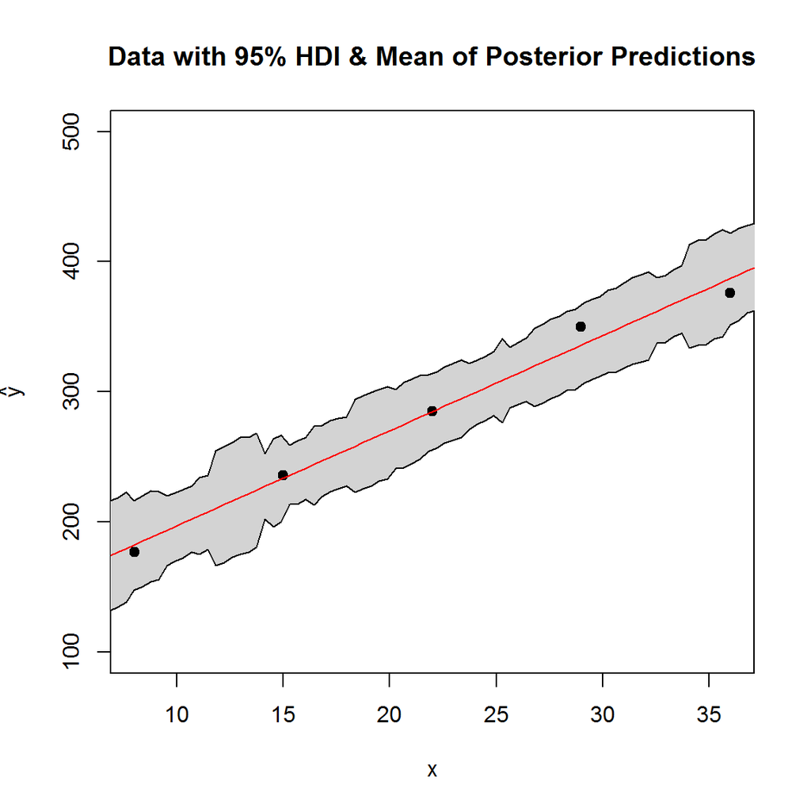

```r
# Display data with HDIs of posterior predictions.
plot( x , y, xlim=c(8,36) , ylim=c(100,500), type="n", ylab=expression(hat(y)),
      main="Data with 95% HDI & Mean of Posterior Predictions")
polygon(c(xPostPred,rev(xPostPred)), c(yHDIlim[,1],rev(yHDIlim[,2])), col="lightgray")  # HDI's
points(x,y, pch=19)
lines( xPostPred , apply(yPostPred,1,mean) , col="red" ) # the linear regression
```

Checking the analytical solution vs. the simulated one:

```r
a <- 1/var(x)
b <- 1/20
A <- matrix(x, ncol=1)                           # d=1, ie, 1D samples

Lambda <- a * t(A) %*% A + b * diag(ncol(A))
mu     <- a * solve(Lambda) %*% t(A) %*% y

i <- 31  # select one of the estimated values
hist(yPostPred[i,], prob=T, breaks=100) # plot the estimated histogram

new.x <- xPostPred[i]
new.x
```

```
## [1] 14.51515
```

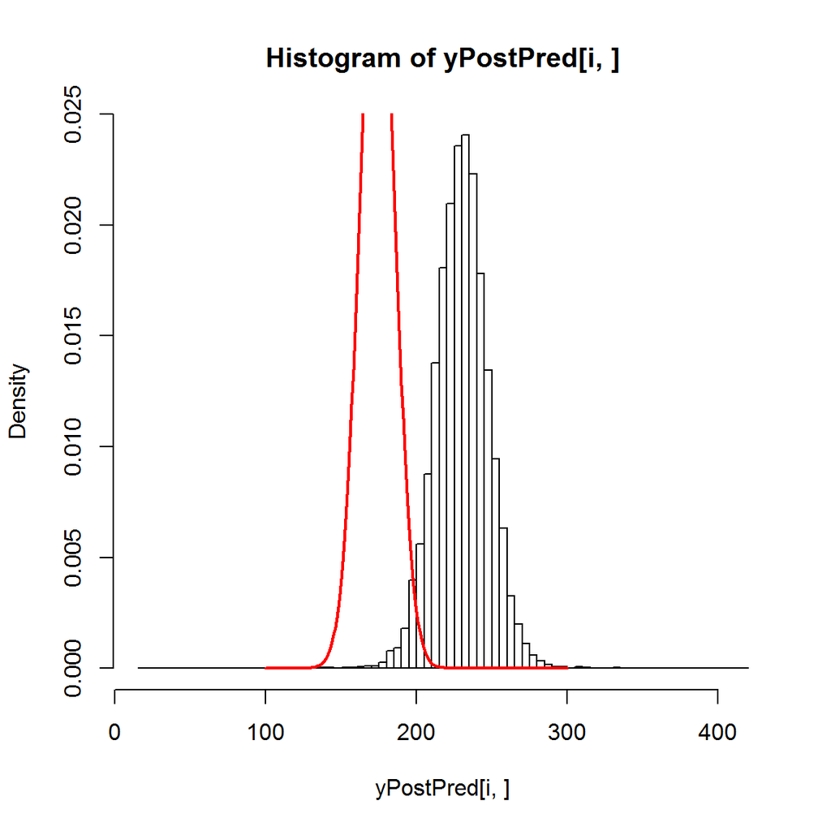

```r
ys <- seq(100,300,1)
lines(ys, dnorm(ys, t(mu)%*%new.x, sqrt(1/a+t(new.x)%*%solve(Lambda)%*%new.x)) , lwd=2, col="red")
```

TODO: this does not fit :-(

## Bayesian Regression with outliers

We got this data somehow (in fact, from [here](http://jakevdp.github.io/blog/2014/06/06/frequentism-and-bayesianism-2-when-results-differ/)).

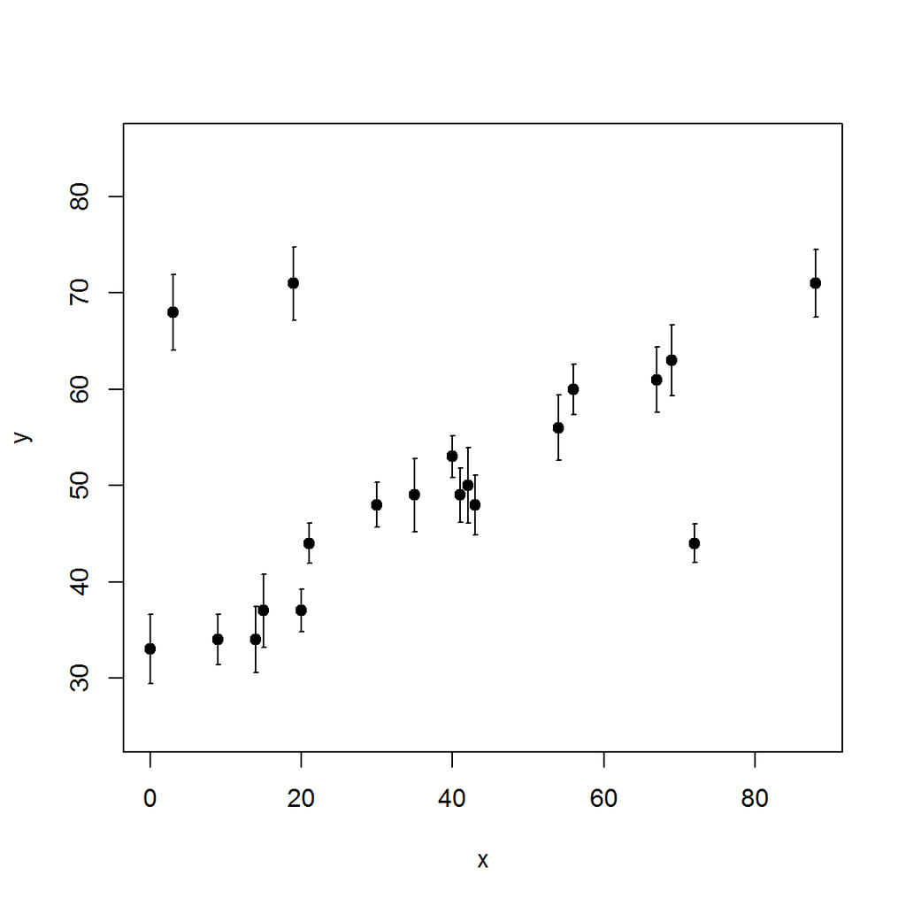

```r
x <- c(0,  3,  9, 14, 15, 19, 20, 21, 30, 35, 40, 41, 42, 43, 54, 56, 67, 69, 72, 88)
y <- c(33, 68, 34, 34, 37, 71, 37, 44, 48, 49, 53, 49, 50, 48, 56, 60, 61, 63, 44, 71)
e <- c(3.6, 3.9, 2.6, 3.4, 3.8, 3.8, 2.2, 2.1, 2.3, 3.8, 2.2, 2.8, 3.9, 3.1, 3.4, 2.6, 3.4, 3.7, 2.0, 3.5) # error of y

plot.errors(x,y,e)
```

We wish to model this using a linear model:

$$\hat{y}(x|\theta) = \theta_0 + \theta_1 x$$

and assume that the likelihood for each point is modelled by a Gaussian:

$$p(x_i,y_i,e_i | \theta) \propto \exp \Big\{ -\frac{1}{2e_i^2} (y - \hat{y}(x|\theta))^2 \Big\}$$

The traditional linear regression gives:

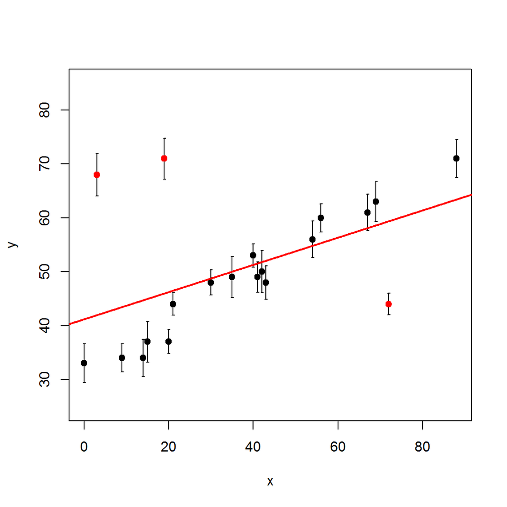

```r
fit <- lm(y~x, data=data.frame(x=x,y=y))
plot.errors(x,y,e)
abline(fit,col="red",lwd=2)                        # showing the linear fit
points(x[c(2,6,19)],y[c(2,6,19)],col="red",pch=19) # showing the outliers
```

which does not seem right at all! This is because of the three obvious outliers (above in red) that influence the result.

We can hack a bit and use the Huber loss function, which is useful to deal with outliers in a classic statistics setting, providing a robust linear regression:

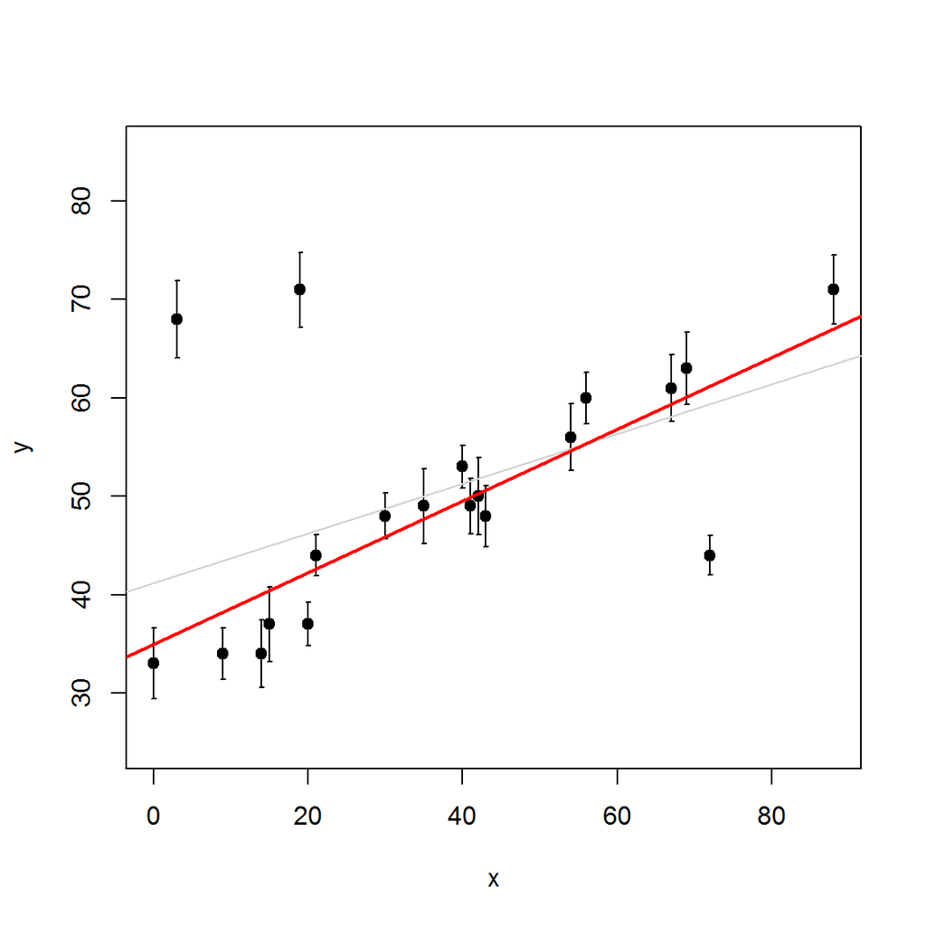

```r
# a: residuals, ie, y - hat.y
huber <- function(a, delta) {
  ifelse(abs(a)<delta, a^2/2, delta*(abs(a)-delta/2))      # ifelse is a vectorized conditional
}

huber.loss <- function(theta, x=x, y=y, e=e, delta=3) {
  sum( huber((y - theta[1] - theta[2]*x)/e, delta) )
}

fit.huber <- optim(par=c(0,0), fn=huber.loss, x=x, y=y, e=e) # find best values using optimization

plot.errors(x,y,e)
abline(fit,col="lightgrey",)                               # showing the linear fit  (in grey)
abline(fit.huber$par[1],fit.huber$par[2], col="red",lwd=2) # showing the robust fit
```

which is way better. However the Huber loss function, and the choice of its parameter value (set here to $3$), are somewhat hacks, *ad hoc* tools to attack the outlier problem.

In Bayesian terms acknowledging the outliers exist, we should modify the model in order to account them.

Now the likelihood will be the following:

$$p(x_i,y_i,e_i | \theta, g_i,\sigma_B) = \frac{g_i}{\sqrt{2\pi e_i^2}} \exp \Big\{ -\frac{1}{2e_i^2} (y - \hat{y}(x|\theta))^2 \Big\} + \frac{1-g_i}{\sqrt{2\pi \sigma_B^2}} \exp \Big\{ -\frac{1}{2 \sigma_B^2} (y - \hat{y}(x|\theta))^2 \Big\}$$

herein, parameter $g_i=0$ means that data point $x_i$ is an outlier, while $g=1$ means that $x_i$ is not. If the i-th point is an outlier the likelihhod will use a Gaussian of variance $\sigma_B$ that might be considered an extra nuissance parameter, or set to a high value (we’ll choose value $50$). Our model has now 22 parameters instead of the initial two ($\theta_0$ and $\theta_1$).

Since BUGS cannot sample from an arbitrary distribution, we can use the [zeros trick](http://users.aims.ac.za/~mackay/BUGS/Manuals/Tricks.html#SpecifyingANewSamplingDistribution) to plug the likelihood directly:

```r
modelString = "
  model {
      for (i in 1:n) {

        phi[i] <- -log( (g[i]/sqrt(2*pi*pow(e[i],2))) * exp(-0.5*pow(y[i]-mu[i],2)/pow(e[i],2)) + ((1-g[i])/sqrt(2*pi*pow(sigmaB,2))) * exp(-0.5*pow(y[i]-mu[i],2)/pow(sigmaB,2)) ) + C

        dummy[i] <- 0
        dummy[i] ~ dpois( phi[i] )

        mu[i] <- theta0 + theta1 * x[i]
        g[i] ~ dunif(0,1)

      }

      theta0 ~ dflat()
      theta1 ~ dflat()

      C <- 10000   # for the zero's trick
      pi <- 3.14159
  }
"

# data
data.list = list(
    x = x,
    y = y,
    e = e,
    n = length(x),
    sigmaB = 50
)

# initializations
n.chains <- 1
theta0 <- c(0)
theta1 <- c(0)
g <- rep(0.01,length(x))

genInitFactory <- function()  {
  i <- 0
  function() {
    i <<- i + 1
    list(
      theta0 = theta0[i],
      theta1 = theta1[i],
      g = g
    )
  }
}

run.model(modelString, samples=c("theta0", "theta1", "g"), data=data.list,
          chainLength=25000, init.func=genInitFactory(), n.chains=n.chains)
```

```
## model is syntactically correct
```

```
## data loaded
```

```
## model compiled
```

```
## Initializing chain 1:
```

```
## model is initialized
```

```
## 2500 updates took 0 s
```

```
## monitor set for variable 'theta0'
```

```
## monitor set for variable 'theta1'
```

```
## monitor set for variable 'g'
```

```
## 25000 updates took 2 s
```

```r
samplesStats(c("theta0", "theta1", "g"))
```

```
##           mean      sd  MC_error val2.5pc  median val97.5pc start sample
## theta0 31.3000 1.63900 0.0295200 28.11000 31.3000   34.5300  2501  25000
## theta1  0.4691 0.03808 0.0006846  0.39430  0.4690    0.5443  2501  25000
## g[1]    0.6410 0.25290 0.0019210  0.10000  0.6821    0.9862  2501  25000
## g[2]    0.3323 0.23560 0.0019900  0.01169  0.2920    0.8410  2501  25000
## g[3]    0.6454 0.25100 0.0021120  0.10510  0.6887    0.9873  2501  25000
## g[4]    0.6259 0.26080 0.0019830  0.07859  0.6691    0.9861  2501  25000
## g[5]    0.6428 0.25060 0.0019230  0.10660  0.6839    0.9868  2501  25000
## g[6]    0.3309 0.23590 0.0018550  0.01264  0.2898    0.8412  2501  25000
## g[7]    0.6030 0.26970 0.0021080  0.06083  0.6436    0.9857  2501  25000
## g[8]    0.6251 0.25990 0.0020680  0.08289  0.6666    0.9860  2501  25000
## g[9]    0.6355 0.25490 0.0018990  0.09566  0.6808    0.9864  2501  25000
## g[10]   0.6408 0.25150 0.0020230  0.10290  0.6826    0.9851  2501  25000
## g[11]   0.6269 0.25850 0.0020520  0.08543  0.6678    0.9859  2501  25000
## g[12]   0.6447 0.25020 0.0020680  0.11000  0.6864    0.9879  2501  25000
## g[13]   0.6407 0.25150 0.0020320  0.10280  0.6832    0.9852  2501  25000
## g[14]   0.6280 0.25930 0.0020200  0.08421  0.6697    0.9853  2501  25000
## g[15]   0.6410 0.24980 0.0018970  0.10880  0.6814    0.9864  2501  25000
## g[16]   0.6396 0.25300 0.0021610  0.10210  0.6811    0.9871  2501  25000
## g[17]   0.6395 0.25200 0.0021170  0.10650  0.6781    0.9869  2501  25000
## g[18]   0.6387 0.25220 0.0022050  0.10650  0.6804    0.9860  2501  25000
## g[19]   0.3346 0.23480 0.0019490  0.01284  0.2962    0.8390  2501  25000
## g[20]   0.6368 0.25400 0.0021190  0.09704  0.6780    0.9856  2501  25000
```

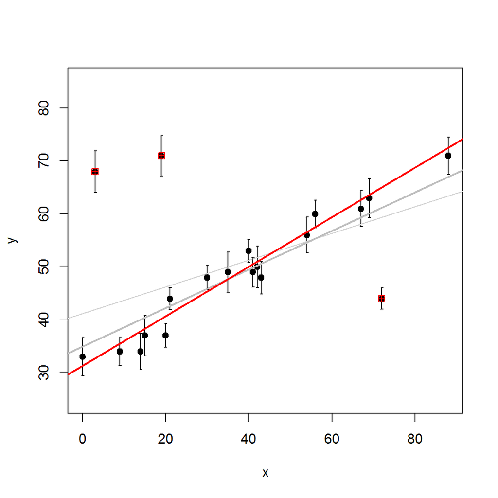

```r
theta0.hat <- mean(samplesSample("theta0"))
theta1.hat <- mean(samplesSample("theta1"))

plot.errors(x,y,e)
abline(fit,col="lightgrey",)                                # showing the linear fit (in grey)
abline(fit.huber$par[1],fit.huber$par[2], col="grey",lwd=2) # showing the robust fit (in solid grey)
abline(theta0.hat, theta1.hat, col="red",lwd=2)
# define outliers as those which g[i] is less than 0.5
posterior.g <- rep(NA,length(g))
for(i in 1:length(g)) {
  posterior.g[i] <- mean(samplesSample(paste0("g[",i,"]")))
}
outliers <- which(posterior.g<0.5)
# plot outliers
points(x[outliers], y[outliers], col="red", pch=12)
```

If we do not care of outlier accounting, we can just use a more heavy-tailed distribution to prevent the outlier influence. The next model uses a t distribution for that effect:

```r
modelString = "
  model {
      for (i in 1:n) {
        tau[i] <- 1/pow(e[i],2)
        y[i] ~ dt(mu[i], tau[i], 4)

        mu[i] <- theta0 + theta1 * x[i]
      }

      theta0 ~ dflat()
      theta1 ~ dflat()
  }
"

data.list = list(
    x = x,
    y = y,
    e = e,
    n = length(x)
)

# initializations
n.chains <- 1
theta0 <- c(0)
theta1 <- c(0)

genInitFactory <- function()  {
  i <- 0
  function() {
    i <<- i + 1
    list(
      theta0 = theta0[i],
      theta1 = theta1[i]
    )
  }
}

run.model(modelString, samples=c("theta0", "theta1"), data=data.list, chainLength=15000,
          init.func=genInitFactory(), n.chains=n.chains)
```

```
## model is syntactically correct
```

```
## data loaded
```

```
## model compiled
```

```
## Initializing chain 1:
```

```
## model is initialized
```

```
## 1500 updates took 0 s
```

```
## monitor set for variable 'theta0'
```

```
## monitor set for variable 'theta1'
```

```
## 15000 updates took 0 s
```

```r
samplesStats(c("theta0", "theta1"))
```

```
##           mean      sd MC_error val2.5pc  median val97.5pc start sample
## theta0 32.1600 1.70100 0.045930  28.9400 32.1400    35.580  1501  15000
## theta1  0.4451 0.03785 0.001012   0.3689  0.4454     0.518  1501  15000
```

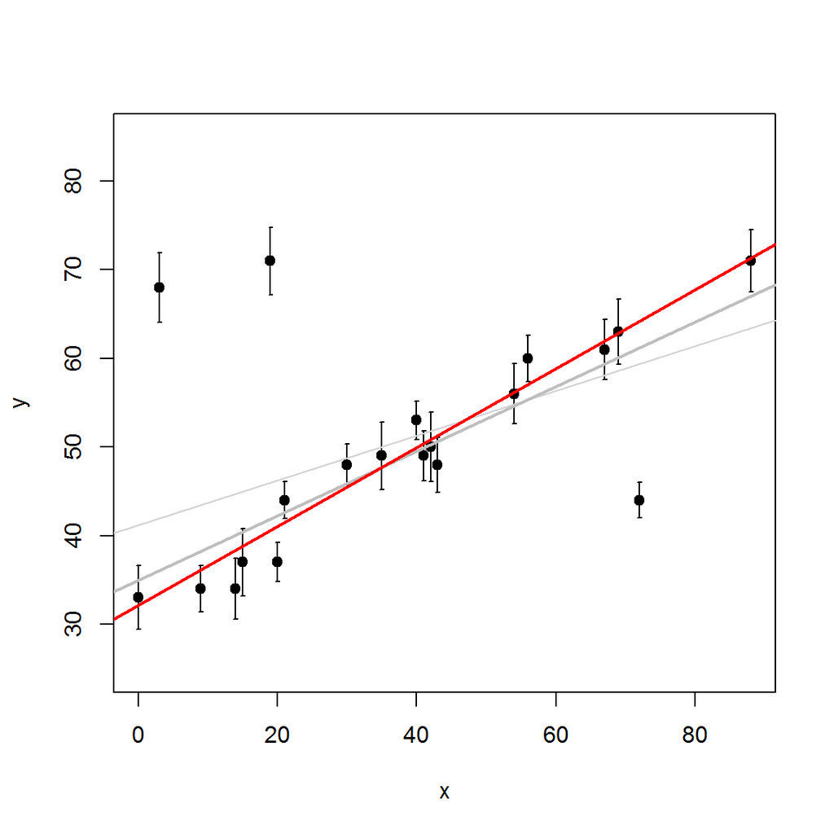

```r
theta0.hat <- mean(samplesSample("theta0"))
theta1.hat <- mean(samplesSample("theta1"))

plot.errors(x,y,e)
abline(fit,col="lightgrey",)                                # showing the linear fit (in grey)
abline(fit.huber$par[1],fit.huber$par[2], col="grey",lwd=2) # showing the robust fit (in solid grey)
abline(theta0.hat, theta1.hat, col="red",lwd=2)
```

## Non-linear Regression

For this eg we’ll use the Gelfand’s dataset of dugongs (sea cows).

The goal is to estimated the size $y_i$ given the age $x_i$.

The model is the following:

$$Y_i = \alpha - \beta \gamma^{x_i} + \epsilon_i, i = 1\ldots,n$$

where $\alpha,\beta>0, 0 \leq \gamma \leq 1$, and the noise $\epsilon_i$ are iid with $\mathcal{N}(0,\sigma^2)$

The interpretation is the following:

- $\alpha$ is the size of a fully grown adult ($x \rightarrow \infty$)
- $\alpha-\beta$ is the dugong’s size at birth
- $\gamma$ is the growth rate (with an initial steep growth, and ending with almost linear growth)

The priors will be:

- flat for $\alpha$ and $\beta$
- uniform from $.01$ to $100$ for $sigma$
- uniform from $.5$ to $1$ for $\gamma$ (not easy to estimate)

```r
modelString = "
  model {
    for( i in 1:N ) {
            y[i] ~ dnorm(mu[i], tau)
            mu[i] <- alpha - beta * pow(gamma, x[i])
        }

        alpha ~ dflat()
        beta  ~ dflat()
        gamma ~ dunif(0.5, 1.0)
    sigma ~ dunif(0.01, 100)
    tau   <- 1/(sigma*sigma)
  }
"

x = c( 1.0,  1.5,  1.5,  1.5, 2.5,   4.0,  5.0,  5.0,   7.0,
       8.0,  8.5,  9.0,  9.5, 9.5,  10.0, 12.0, 12.0,  13.0,
       13.0, 14.5, 15.5, 15.5, 16.5, 17.0, 22.5, 29.0, 31.5)

y = c(1.80, 1.85, 1.87, 1.77, 2.02, 2.27, 2.15, 2.26, 2.47,
      2.19, 2.26, 2.40, 2.39, 2.41, 2.50, 2.32, 2.32, 2.43,
      2.47, 2.56, 2.65, 2.47, 2.64, 2.56, 2.70, 2.72, 2.57)

data.list = list(
  x = x,
    y = y,
  N = length(x))

# initializations
n.chains <- 3
alpha <- c(1,10,100)
beta  <- c(1,10,100)
gamma <- c(.9,.7,.5)
sigma <- c(1,10,100)

genInitFactory <- function()  {
  i <- 0
  function() {
    i <<- i + 1
    list(
      alpha = alpha[i],
      beta  = beta[i],
      gamma = gamma[i],
      sigma = sigma[i]
    )
  }
}

run.model(modelString, samples=c("alpha", "beta", "gamma", "sigma"), data=data.list,
          chainLength=50000, init.func=genInitFactory(), n.chains=n.chains)
```

```
## model is syntactically correct
```

```
## data loaded
```

```
## model compiled
```

```
## Initializing chain 1:
```

```
## Initializing chain 2:
```

```
## Initializing chain 3:
```

```
## model is initialized
```

```
## 5000 updates took 3 s
```

```
## monitor set for variable 'alpha'
```

```
## monitor set for variable 'beta'
```

```
## monitor set for variable 'gamma'
```

```
## monitor set for variable 'sigma'
```

```
## 50000 updates took 31 s
```

```r
samplesStats(c("alpha", "beta", "gamma", "sigma"))
```

```
##         mean      sd  MC_error val2.5pc  median val97.5pc start sample
## alpha 2.6520 0.07366 9.429e-04   2.5280 2.64600    2.8160  5001 150000
## beta  0.9739 0.07879 5.028e-04   0.8230 0.97240    1.1330  5001 150000
## gamma 0.8619 0.03379 3.910e-04   0.7839 0.86570    0.9163  5001 150000
## sigma 0.1009 0.01572 6.209e-05   0.0758 0.09904    0.1370  5001 150000
```

So, let’s plot the results:

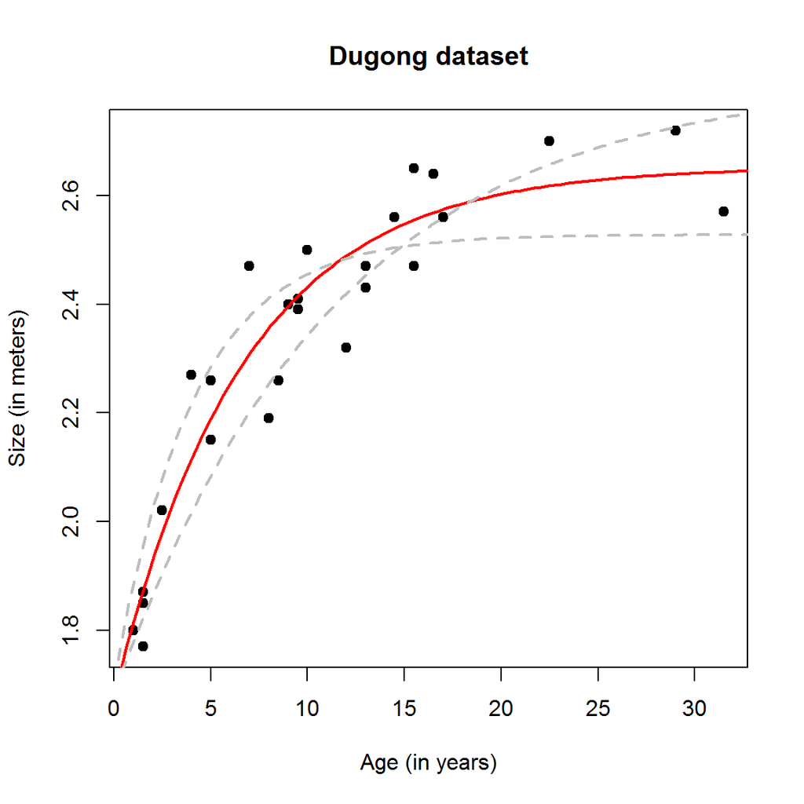

```r
alpha.hat <- mean(samplesSample("alpha"))
beta.hat  <- mean(samplesSample("beta"))
gamma.hat <- mean(samplesSample("gamma"))

plot(x,y,pch=19,xlab="Age (in years)", ylab="Size (in meters)",main="Dugong dataset")
curve(alpha.hat - beta.hat * gamma.hat^x, from=0, to=35, col="red", lwd=2, add=T) # plot estimation

# draw 2.5% and 97.5% growth curves
alpha2.5 <- samplesStats(c("alpha"))$val2.5pc
beta2.5  <- samplesStats(c("beta"))$val2.5pc
gamma2.5 <- samplesStats(c("gamma"))$val2.5pc

alpha97.5 <- samplesStats(c("alpha"))$val97.5pc
beta97.5  <- samplesStats(c("beta"))$val97.5pc
gamma97.5 <- samplesStats(c("gamma"))$val97.5pc

curve(alpha97.5 - beta97.5 * gamma97.5^x, from=0, to=35, col="grey", lwd=2, lty=2, add=T)
curve(alpha2.5  - beta2.5  * gamma2.5^x,  from=0, to=35, col="grey", lwd=2, lty=2, add=T)
```

## Generalized Linear Modelling

Linear Regression predicts that the expected value of the dependent/response variable $y$ is a linear combination of the independent/observed variables $x_i$. This is appropriate when the response variable is modelled by a normal distribution. If this does not happen, linear regression is not suitable.

If, for eg, the response $y$ is an exponential combination of $x$, then it is its logarithm that has a linear combination. This is called a log-linear model.

Another eg is if $y$ is a boolean response. Then, say, if an increase of $x$ increases the probability of $y=1$, then the response might be a linear combination of the odds or the logarithm of the odds. This last eg is called a log-odds (aks logit) model.

Generalized Linear Modelling (GLM) is a generalization of linear regression in the sense that it allows $y$ to have an arbitrary distribution, and that a certain function $g$ of $y$ to vary linearly with $x$. The function $g$ is called the *link function*.

For the previous exponential eg $y$ can be modelled by a Poisson and $g(x)=log(x)$. For the 2nd eg, $y$ might be modelled by a Bernoulli while the link function is $g(x)=logit(x)=log(x/(1-x))$

The GLM assumes $Y$ has distribution from the exponential family, like a Bernoulli, Binomial, Poisson, Exponential, Laplace, Normal, Gamma, …

$$E[Y_i] = g^{-1}(\beta_0 + \sum_k \beta_k x_{ki})$$

For GLM to work there’s the need of a distribution for $Y$, a link function $g$, and the linear predictor which can be found using several techniques, herein we’ll use BUGS (surprise!).

## GLM with a Bernoulli: Logistic Regression

Assume we have a binary version of the previous dugong dataset, considering only a criteria to decide if a dugong is full grown (we no longer have access to $y_i$). In this case, our new response $Z$ is defined as $1$ if $y>2.4$, or $0$ otherwise:

```r
z <- as.numeric(y>2.4)
z
```

```
##  [1] 0 0 0 0 0 0 0 0 1 0 0 0 0 1 1 0 0 1 1 1 1 1 1 1 1 1 1
```

To apply GLM (cf. section above) we choose:

- $Y \sim$ Bernoulli
- The logit link function
- BUGS to find the linear predictor, ie, the values of $\beta$

A logistic model for $p_i = P(Z_i=1|X_i)$ is

$$logit(p_i) = \log(\frac{p_i}{1-p_i}) = \beta_0 + \beta_1 \log(x_i)$$

```r
modelString = "
  model {
    for( i in 1:N) {
      z[i] ~ dbern( p[i] )

      # necessary to subtract the mean (ie, center x) to prevent MCMC convergence issues
      logit(p[i]) <- beta0 + beta1 * (logAge[i] - mean(logAge[]))  # logistic model
      logAge[i]  <- log(x[i])
    }

    beta0 ~ dflat()
    beta1 ~ dflat()
  }
"

data.list = list(
  x = x,
  z = z,
  N = length(x))

# initializations
beta0  <- c(0)
beta1  <- c(0)

genInitFactory <- function()  {
  i <- 0
  function() {
    i <<- i + 1
    list(
      beta0 = beta0[i],
      beta1 = beta1[i]
    )
  }
}

run.model(modelString, samples=c("beta0", "beta1"), data=data.list,
          chainLength=50000, init.func=genInitFactory(), n.chains=1)
```

```
## model is syntactically correct
```

```
## data loaded
```

```
## model compiled
```

```
## Initializing chain 1:
```

```
## model is initialized
```

```
## 5000 updates took 0 s
```

```
## monitor set for variable 'beta0'
```

```
## monitor set for variable 'beta1'
```

```
## 50000 updates took 1 s
```

```r
samplesStats(c("beta0", "beta1"))
```

```
##         mean    sd MC_error val2.5pc median val97.5pc start sample
## beta0 -1.505 0.961  0.01582   -3.704 -1.420    0.1096  5001  50000
## beta1  6.154 2.482  0.04349    2.358  5.811   12.1300  5001  50000
```

Plotting the results:

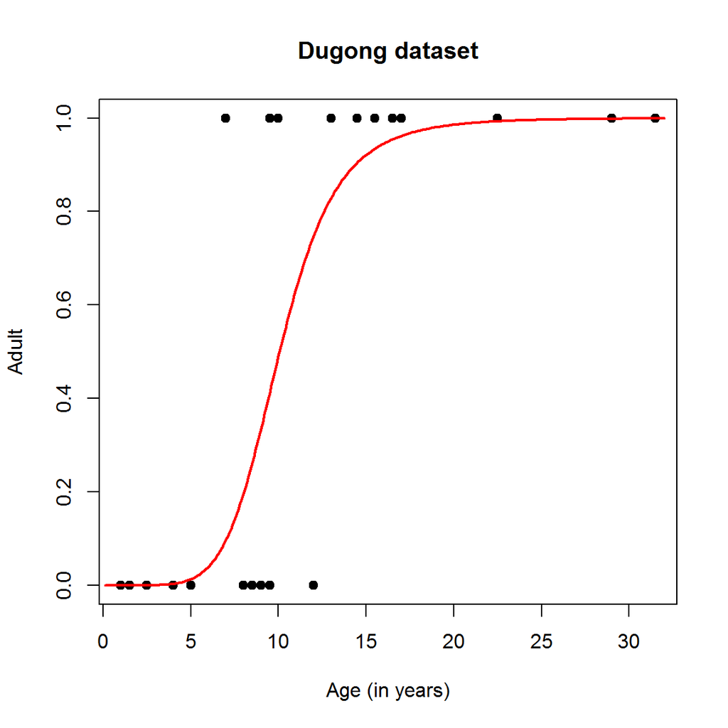

```r
beta0.hat  <- mean(samplesSample("beta0"))
beta1.hat  <- mean(samplesSample("beta1"))

plot(x,z,pch=19,xlab="Age (in years)", ylab="Adult", main="Dugong dataset")
# draw the estimated values for E[Y_i] (it is a logistic curve)
xs <- seq(0.1,32,.1)
exp.logit <- exp( beta0.hat + beta1.hat*(log(xs) - mean(log(x))) )
lines(xs,exp.logit/(1+exp.logit), col="red", lwd=2) # plot estimation
```

For instance, what is the probability that a dugong with $8$ years is full grown?

```r
x.new <- 8
exp.logit.new <- exp( beta0.hat + beta1.hat*(log(x.new) - mean(log(x))) )
exp.logit.new/(1+exp.logit.new)
```

```
## [1] 0.1962679
```

## GLM: Poisson Regression

In Poisson Regression, usually used to express number of successes within a fixed time interval, we choose:

- $Y_i \sim$ Poisson($\lambda_i$)
- The log link function
- BUGS to find the linear predictor, ie, the values of $\beta$

A log-linear model for $\lambda$ is

$$\log(\lambda_i) = \beta_0 + \beta_1 x_i$$

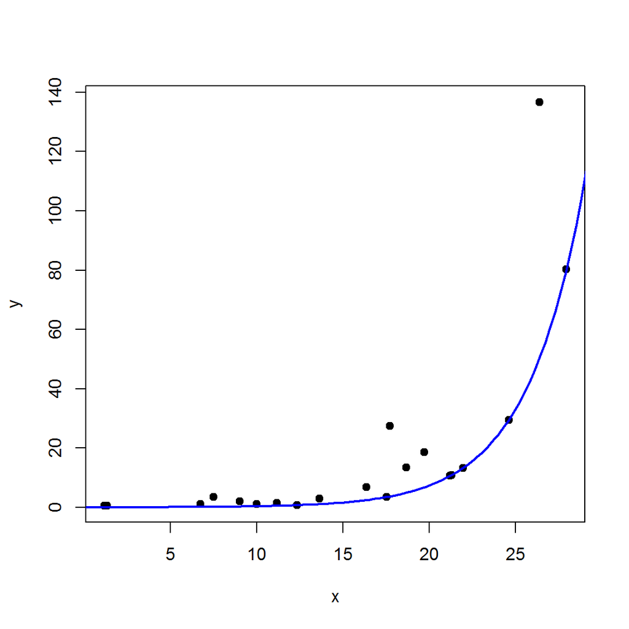

```r
set.seed(101)
n <- 20
x <- runif(n,0,30)
beta.0 <- -4
beta.1 <- 0.3
y <- exp( beta.0 + beta.1*x + rpois(n,1.0) )
plot(x,y,pch=19)
xs <- seq(.1,30,len=101)
lines(xs,exp(beta.0 + beta.1*xs),lwd=2,col="blue")
```

```r
modelString = "
  model {
    for( i in 1:N) {
      y[i] ~ dpois( lambda[i] )

      log(lambda[i]) <- beta0 + beta1 * x[i]
    }

    beta0 ~ dnorm(0,0.0001)
    beta1 ~ dnorm(0,0.0001)
  }
"

data.list = list(
  x = x,
  y = y,
  N = n)

# initializations
beta0  <- c(0)
beta1  <- c(1)

genInitFactory <- function()  {
  i <- 0
  function() {
    i <<- i + 1
    list(
      beta0 = beta0[i],
      beta1 = beta1[i]
    )
  }
}

run.model(modelString, samples=c("beta0", "beta1"), data=data.list,
          chainLength=250000, init.func=genInitFactory(), n.chains=1)
```

```
## model is syntactically correct
```

```
## data loaded
```

```
## model compiled
```

```
## Initializing chain 1:
```

```
## model is initialized
```

```
## 25000 updates took 0 s
```

```
## monitor set for variable 'beta0'
```

```
## monitor set for variable 'beta1'
```

```
## 250000 updates took 5 s
```

```r
samplesStats(c("beta0", "beta1"))
```

```
##          mean      sd  MC_error val2.5pc  median val97.5pc start sample
## beta0 -2.2020 0.30540 0.0025220  -2.8150 -2.1960   -1.6150 25001 250000
## beta1  0.2465 0.01261 0.0001021   0.2222  0.2463    0.2718 25001 250000
```

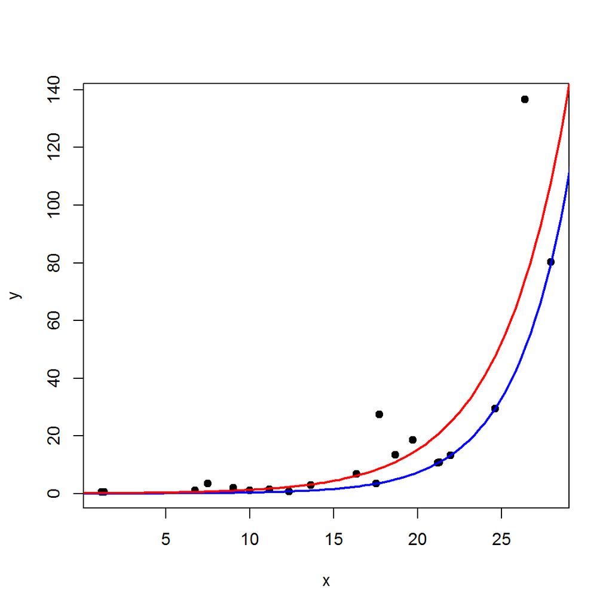

```r
beta0.hat  <- mean(samplesSample("beta0"))
beta1.hat  <- mean(samplesSample("beta1"))

plot(x,y,pch=19)
xs <- seq(.1,30,len=101)
lines(xs,exp(beta.0 + beta.1*xs),lwd=2,col="blue")      # target function
lines(xs,exp(beta0.hat + beta1.hat*xs),lwd=2,col="red") # proposed function
```

## Mixture of Gaussians

Let’s say we have this dataset (taken from [Bayesian Methods for Hackers](http://camdavidsonpilon.github.io/Probabilistic-Programming-and-Bayesian-Methods-for-Hackers/)):

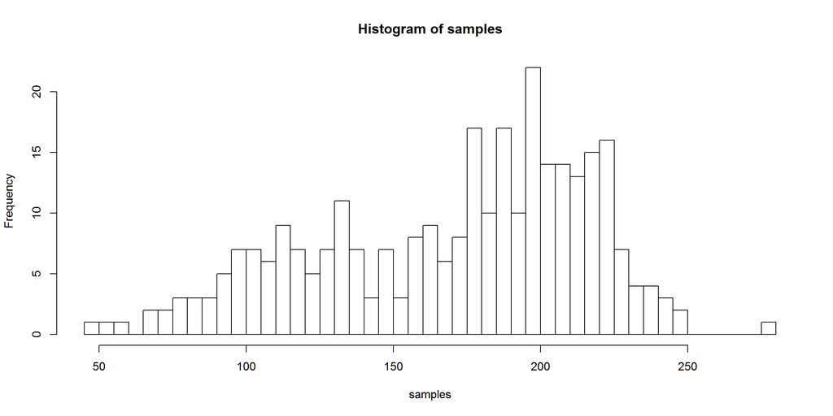

```r
samples <- read.csv("mixture_data.csv", header=F)[,1]
hist(samples, breaks=40)
```

It appears the data has a bimodal form, one peak around 120 and another at 200.

Our model proposes that the dataset has two clusters of data, each produced by a normal distribution. The construction was:

1. For each data point $y_i$:
2. choose distribution 1 with probability $p$, or distribution 2 with probability $1-p$
3. Draw one random sample from the chosen distribution $\mathcal{N}(\mu_k, \sigma_k)$, $k=1,2$

So, our model is

$$G_i \sim \text{Binomial}(p)$$

$$y_i \sim \mathcal{N}(\mu_{G_i}, \sigma_{G_i})$$

$$\mu_k \sim \mathcal{N}(0,1000)$$

$$\sigma_k \sim \text{Gamma}(0.01, 0.01)$$

$G_i$ means the cluster of the i-th datapoint; in this problem $G_i = \{1,2\}$. In the following model, it is used `dcat` instead of a binomial, just because this way it can also work with more than two clusters.

```r
modelString = "
# BUGS model specification begins ...

model {

  for( i in 1 : N ) {
     y[i]   ~  dnorm(mu[i], tau[i])  # likelihood
     mu[i]  <- lambda[G[i]]          # prior for mean
     tau[i] <- lambdaTau[G[i]]       # prior for precision
     G[i]   ~  dcat(P[])             # the cluster attributions for each y_i
  }

  P[1:2] ~ ddirch(alpha[])           # dirichlet distribution (in this case just for 2 clusters)
  alpha[1] <- 0.5                    # It generalizes the beta (with K=2 we could have used the beta), and
  alpha[2] <- 0.5                    # is the conjugate for the categorical distribution

  lambda[1] ~ dnorm(0.0, 1.0E-6)     # hyperparameters for mean
  lambda[2] <- lambda[1] + theta
  theta ~ dnorm(0.0, 1.0E-6)I(0.0, )

  lambdaTau[1] ~ dgamma(0.01,0.01)   # hyperparameters for precision/standard deviation
  lambdaTau[2] ~ dgamma(0.01,0.01)

  sigma[1] <- 1 / sqrt(lambdaTau[1])
  sigma[2] <- 1 / sqrt(lambdaTau[2])
}

# ... BUGS model specification ends.
" # close quote to end modelString
```

There is a trick here. To prevent divergence issues (all datapoints selected to a single cluster), the second mean hyperparameter, $\lambda_2$, is determined this way: $\lambda_2 = \lambda_1 + \theta, \theta \gt 0$ (check Bugs Book, pages 280-3).

```r
data.list = list(
  y = samples,
  N = length(samples),
  G = c(1, rep(NA,length(samples)-2), 2)  # TODO: do not understand these 1 and 2
)

# let's apply some thinning to the mcmc:
run.model(modelString, samples=c("sigma", "lambda", "P", "G"), data=data.list, chainLength=3e4, thin=4)
```

```
## model is syntactically correct
```

```
## data loaded
```

```
## model compiled
```

```
## 3000 updates took 1 s
```

```
## monitor set for variable 'sigma'
```

```
## monitor set for variable 'lambda'
```

```
## monitor set for variable 'P'
```

```
## monitor set for variable 'G'
```

```
## 30000 updates took 19 s
```

```r
samplesStats("sigma")
```

```
##           mean    sd MC_error val2.5pc median val97.5pc start sample
## sigma[1] 31.53 5.310  0.25370    23.59  30.61     44.25  3001   7500
## sigma[2] 22.18 2.204  0.08703    17.61  22.23     26.41  3001   7500
```

```r
samplesStats("lambda")
```

```
##            mean    sd MC_error val2.5pc median val97.5pc start sample
## lambda[1] 122.8 8.485   0.4445    110.4  121.1     144.5  3001   7500
## lambda[2] 200.7 3.047   0.1237    195.0  200.6     206.8  3001   7500
```

```r
samplesStats("P")
```

```
##        mean      sd MC_error val2.5pc median val97.5pc start sample
## P[1] 0.3975 0.07069 0.003455   0.2898  0.386    0.5789  3001   7500
## P[2] 0.6025 0.07069 0.003455   0.4211  0.614    0.7102  3001   7500
```

```r
samplesCorrel("sigma[1]", "sigma[2]") # the correlation is negative: one sd larger means the other is smaller
```

```
##          sigma.2.
## sigma[1]  -0.6214
```

Let’s vizualize the results:

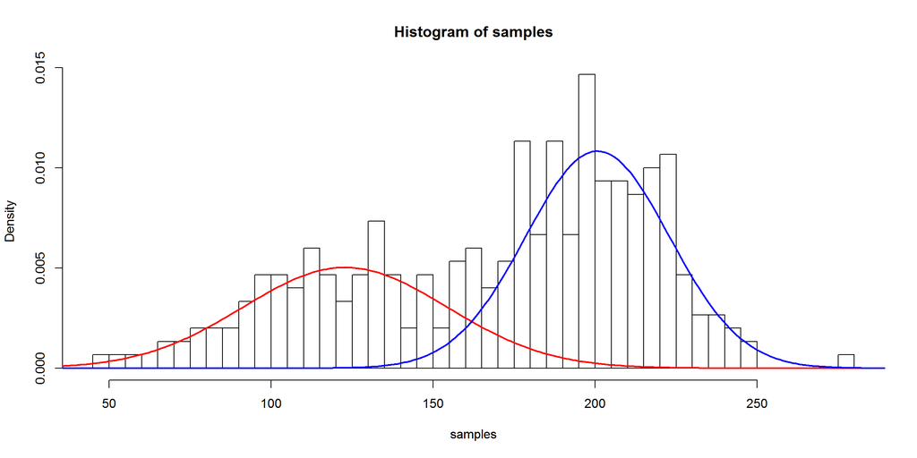

```r
p <- samplesStats("P")$mean[1]

mu1.hat    <- samplesStats("lambda")$mean[1]
mu2.hat    <- samplesStats("lambda")$mean[2]
sigma1.hat <- samplesStats("sigma")$mean[1]
sigma2.hat <- samplesStats("sigma")$mean[2]

hist(samples, breaks=40, prob=T)
xs <- 0:300
lines(xs,  p  *dnorm(xs,mu1.hat,sigma1.hat), col="red",  lwd=2)
lines(xs,(1-p)*dnorm(xs,mu2.hat,sigma2.hat), col="blue", lwd=2)
```

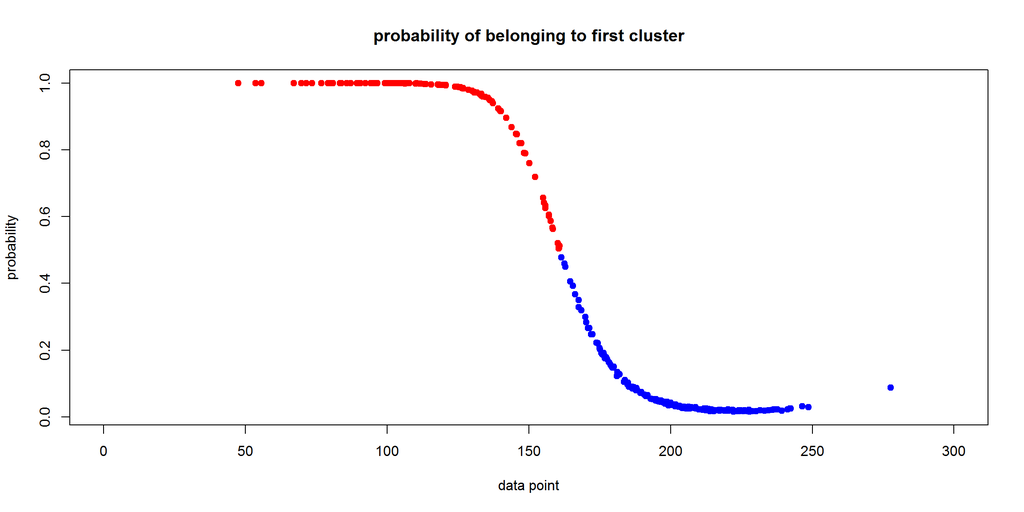

```r
prob.cluster.1 <- 2 - samplesStats("G")[,1]
# need to remove the first and last observations until the previous TODO is solved
plot(samples[c(-1,-300)], prob.cluster.1, col = c("blue","red")[1+round(prob.cluster.1)], xlim=c(0,300),
     xlab="data point", ylab="probability", main="probability of belonging to first cluster", pch=19)
```

Let’s also use BRugs graphical tools:

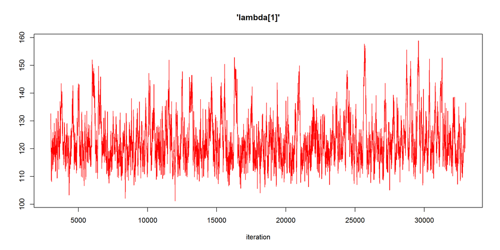

```r
# cannot use samplesHistory("*") because of nodes G[]
samplesHistory("lambda[1]", mfrow = c(1, 1))
```

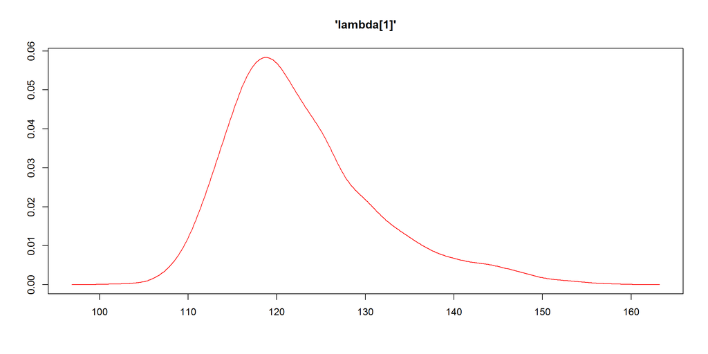

```r
samplesDensity("lambda[1]", mfrow = c(1, 1))
```

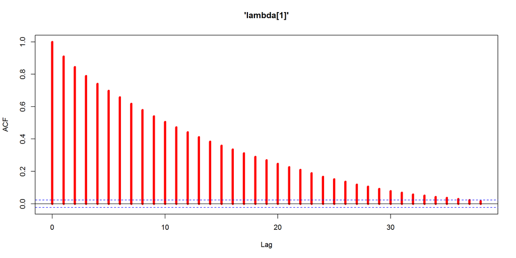

```r
samplesAutoC("lambda[1]", mfrow = c(1, 1), 1)
```